# Assignment2

# Problem 1: Applying k-Nearest Neighbors

## Data Exploration

### Summary

```r
# Read in the data set, converting both "unknown" and -1 values to NA
bank_full <- read.csv("bank-full.csv", sep=";", na.strings=c("unknown", -1))
str(bank_full)
```

```
## 'data.frame':    45211 obs. of  17 variables:
##  $ age      : int  58 44 33 47 33 35 28 42 58 43 ...
##  $ job      : chr  "management" "technician" "entrepreneur" "blue-collar" ...
##  $ marital  : chr  "married" "single" "married" "married" ...
##  $ education: chr  "tertiary" "secondary" "secondary" NA ...
##  $ default  : chr  "no" "no" "no" "no" ...
##  $ balance  : int  2143 29 2 1506 1 231 447 2 121 593 ...
##  $ housing  : chr  "yes" "yes" "yes" "yes" ...
##  $ loan     : chr  "no" "no" "yes" "no" ...
##  $ contact  : chr  NA NA NA NA ...
##  $ day      : int  5 5 5 5 5 5 5 5 5 5 ...
##  $ month    : chr  "may" "may" "may" "may" ...
##  $ duration : int  261 151 76 92 198 139 217 380 50 55 ...
##  $ campaign : int  1 1 1 1 1 1 1 1 1 1 ...
##  $ pdays    : int  NA NA NA NA NA NA NA NA NA NA ...
##  $ previous : int  0 0 0 0 0 0 0 0 0 0 ...
##  $ poutcome : chr  NA NA NA NA ...
##  $ y        : chr  "no" "no" "no" "no" ...
```

```r
summary(bank_full)
```

```
##       age            job              marital           education
##  Min.   :18.00   Length:45211       Length:45211       Length:45211
##  1st Qu.:33.00   Class :character   Class :character   Class :character
##  Median :39.00   Mode  :character   Mode  :character   Mode  :character
##  Mean   :40.94
##  3rd Qu.:48.00
##  Max.   :95.00
##
##    default             balance         housing              loan
##  Length:45211       Min.   : -8019   Length:45211       Length:45211
##  Class :character   1st Qu.:    73   Class :character   Class :character
##  Mode  :character   Median :   450   Mode  :character   Mode  :character
##                     Mean   :  1364
##                     3rd Qu.:  1430
##                     Max.   :102127
##                     NA's   :50
##    contact               day           month              duration
##  Length:45211       Min.   : 1.00   Length:45211       Min.   :   0.0
##  Class :character   1st Qu.: 8.00   Class :character   1st Qu.: 103.0
##  Mode  :character   Median :16.00   Mode  :character   Median : 180.0
##                     Mean   :15.81                      Mean   : 258.2
##                     3rd Qu.:21.00                      3rd Qu.: 319.0
##                     Max.   :31.00                      Max.   :4918.0
##
##     campaign          pdays          previous          poutcome
##  Min.   : 1.000   Min.   :  1.0   Min.   :  0.0000   Length:45211
##  1st Qu.: 1.000   1st Qu.:133.0   1st Qu.:  0.0000   Class :character
##  Median : 2.000   Median :194.0   Median :  0.0000   Mode  :character
##  Mean   : 2.764   Mean   :224.6   Mean   :  0.5803
##  3rd Qu.: 3.000   3rd Qu.:327.0   3rd Qu.:  0.0000
##  Max.   :63.000   Max.   :871.0   Max.   :275.0000
##                   NA's   :36954
##       y
##  Length:45211
##  Class :character
##  Mode  :character
##
##
##
##
```

### Variable types

- `age`: continuous
- `job`: nominal categorical
- `marital`: nominal categorical
- `education`: ordinal discrete
- `default`: nominal categorical
- `balance`: continuous
- `housing`: nominal categorical
- `loan`: nominal categorical
- `contact`: nominal categorical
- `day`: continuous
- `month`: nominal categorical
- `duration`: continuous
- `campaign`: continuous
- `pdays`: continuous
- `previous`: continuous
- `poutcome`: nominal categorical
- `y`: nominal categorical

### `y` Analysis

```r
table(bank_full$y)
```

```
##
##    no   yes
## 39922  5289
```

There are many more “no”s than “yes”s in the data set, indicating that `y` is not balanced.

### `y` Associations

Categorical to categorical: CrossTable & Mosaic Plot Categorical to numerical: Side-By-Side Box Plot Categorical to Ordinal: One-Way ANOVA

#### Mosaic Plots and ChiSquare Tests | Side-By-Side Boxplots and Two Sample T-Test | One-Way ANOVA

We can perform Mosaic Plots and ChiSquare Tests on the nominal data, Side-By-Side Boxplots on the continuous data, and One-Way ANOVA tests on the ordinal data using the following code:

```r
# setup
library(gmodels)
library(vcd)
```

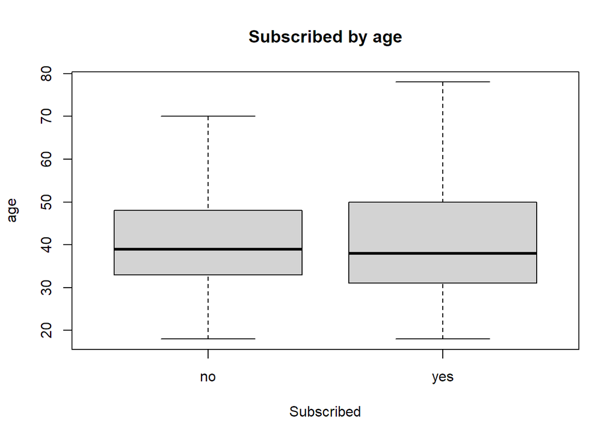

```
##
##  Welch Two Sample t-test
##
## data:  otherC by y
## t = -4.3183, df = 6109.2, p-value = 1.597e-05
## alternative hypothesis: true difference in means between group no and group yes is not equal to 0
## 95 percent confidence interval:
##  -1.2083645 -0.4538034
## sample estimates:
##  mean in group no mean in group yes
##          40.83899          41.67007
```

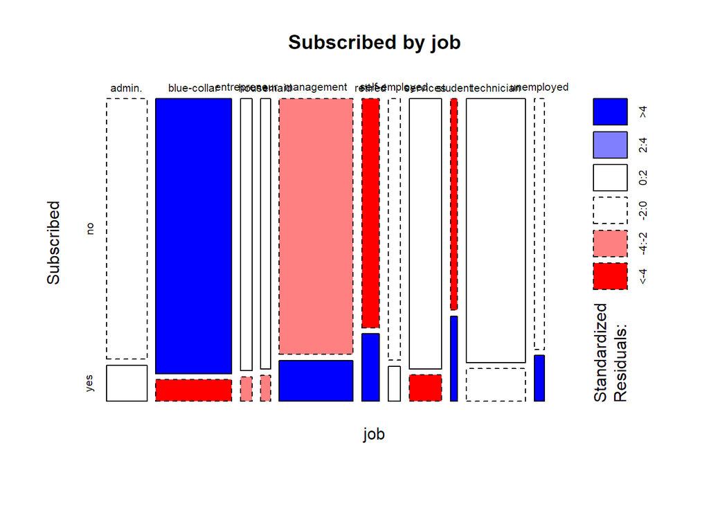

```
##
##
##    Cell Contents
## |-------------------------|
## |                       N |
## | Chi-square contribution |
## |           N / Row Total |
## |           N / Col Total |
## |         N / Table Total |
## |-------------------------|
##
##
## Total Observations in Table:  44923
##
##
##               | y
##        otherC |        no |       yes | Row Total |
## --------------|-----------|-----------|-----------|
##        admin. |      4540 |       631 |      5171 |
##               |     0.149 |     1.127 |           |
##               |     0.878 |     0.122 |     0.115 |
##               |     0.114 |     0.120 |           |
##               |     0.101 |     0.014 |           |
## --------------|-----------|-----------|-----------|
##   blue-collar |      9024 |       708 |      9732 |
##               |    21.559 |   162.741 |           |
##               |     0.927 |     0.073 |     0.217 |
##               |     0.227 |     0.135 |           |
##               |     0.201 |     0.016 |           |
## --------------|-----------|-----------|-----------|
##  entrepreneur |      1364 |       123 |      1487 |
##               |     1.977 |    14.921 |           |
##               |     0.917 |     0.083 |     0.033 |
##               |     0.034 |     0.023 |           |
##               |     0.030 |     0.003 |           |
## --------------|-----------|-----------|-----------|
##     housemaid |      1131 |       109 |      1240 |
##               |     1.187 |     8.961 |           |
##               |     0.912 |     0.088 |     0.028 |
##               |     0.029 |     0.021 |           |
```

[output cut: 43 more lines]

```
## --------------|-----------|-----------|-----------|
##  Column Total |     39668 |      5255 |     44923 |
##               |     0.883 |     0.117 |           |
## --------------|-----------|-----------|-----------|
##
##
## Statistics for All Table Factors
##
##
## Pearson's Chi-squared test
## ------------------------------------------------------------
## Chi^2 =  836.1448     d.f. =  10     p =  3.486711e-173
##
##
##
```

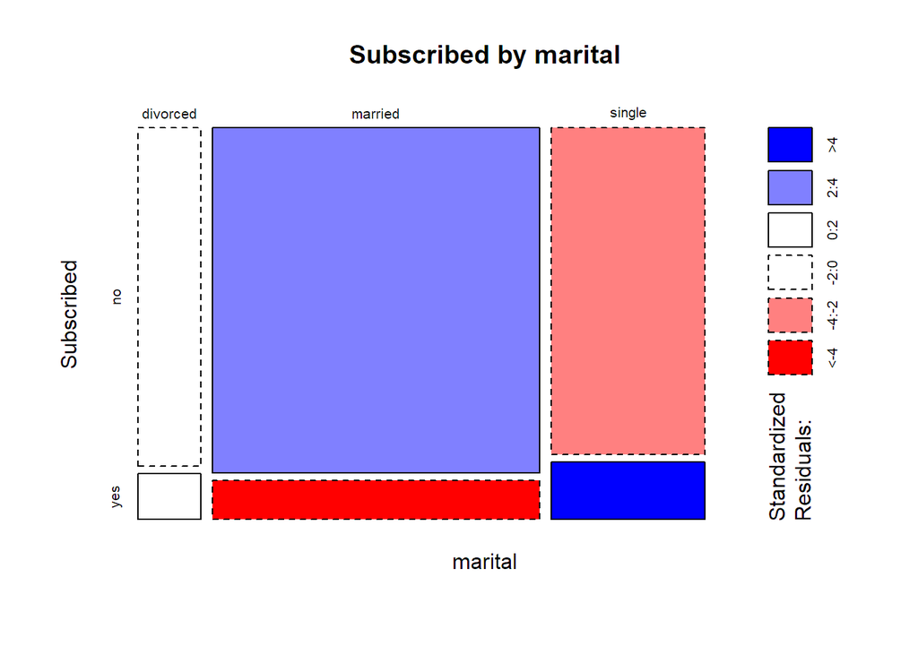

```
##
##
##    Cell Contents
## |-------------------------|
## |                       N |
## | Chi-square contribution |
## |           N / Row Total |
## |           N / Col Total |
## |         N / Table Total |
## |-------------------------|
##
##
## Total Observations in Table:  45211
##
##
##              | y
##       otherC |        no |       yes | Row Total |
## -------------|-----------|-----------|-----------|
##     divorced |      4585 |       622 |      5207 |
##              |     0.036 |     0.272 |           |
##              |     0.881 |     0.119 |     0.115 |
##              |     0.115 |     0.118 |           |
##              |     0.101 |     0.014 |           |
## -------------|-----------|-----------|-----------|
##      married |     24459 |      2755 |     27214 |
##              |     7.645 |    57.707 |           |
##              |     0.899 |     0.101 |     0.602 |
##              |     0.613 |     0.521 |           |
##              |     0.541 |     0.061 |           |
## -------------|-----------|-----------|-----------|
##       single |     10878 |      1912 |     12790 |
##              |    15.306 |   115.530 |           |
##              |     0.851 |     0.149 |     0.283 |
##              |     0.272 |     0.362 |           |
##              |     0.241 |     0.042 |           |
## -------------|-----------|-----------|-----------|
## Column Total |     39922 |      5289 |     45211 |
##              |     0.883 |     0.117 |           |
## -------------|-----------|-----------|-----------|
##
##
## Statistics for All Table Factors
##
##
## Pearson's Chi-squared test
## ------------------------------------------------------------
## Chi^2 =  196.4959     d.f. =  2     p =  2.1451e-43
##
##
##
```

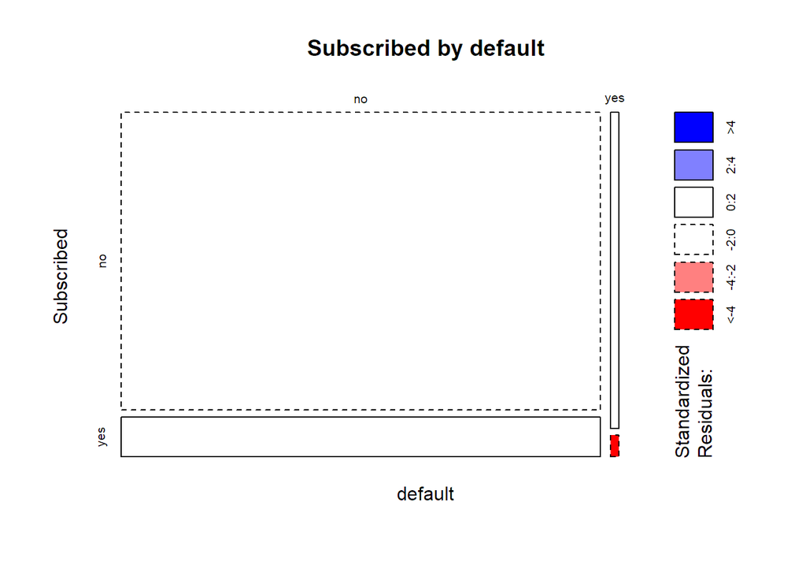

```
##
##
##    Cell Contents
## |-------------------------|
## |                       N |
## | Chi-square contribution |
## |           N / Row Total |
## |           N / Col Total |
## |         N / Table Total |
## |-------------------------|
##
##
## Total Observations in Table:  45211
##
##
##              | y
##       otherC |        no |       yes | Row Total |
## -------------|-----------|-----------|-----------|
##           no |     39159 |      5237 |     44396 |
##              |     0.048 |     0.362 |           |
##              |     0.882 |     0.118 |     0.982 |
##              |     0.981 |     0.990 |           |
##              |     0.866 |     0.116 |           |
## -------------|-----------|-----------|-----------|
##          yes |       763 |        52 |       815 |
##              |     2.610 |    19.703 |           |
##              |     0.936 |     0.064 |     0.018 |
##              |     0.019 |     0.010 |           |
##              |     0.017 |     0.001 |           |
## -------------|-----------|-----------|-----------|
## Column Total |     39922 |      5289 |     45211 |
##              |     0.883 |     0.117 |           |
## -------------|-----------|-----------|-----------|
##
##
## Statistics for All Table Factors
##
##
## Pearson's Chi-squared test
## ------------------------------------------------------------
## Chi^2 =  22.7235     d.f. =  1     p =  1.870659e-06
##
## Pearson's Chi-squared test with Yates' continuity correction
## ------------------------------------------------------------
## Chi^2 =  22.20225     d.f. =  1     p =  2.453861e-06
##
##
```

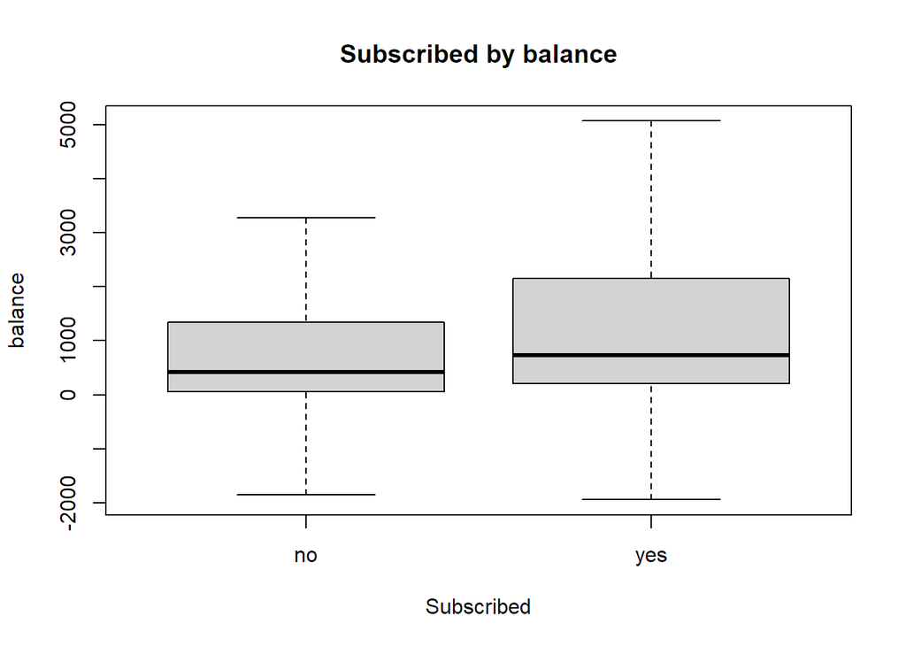

```
##
##  Welch Two Sample t-test
##
## data:  otherC by y
## t = -9.9239, df = 6335.8, p-value < 2.2e-16
## alternative hypothesis: true difference in means between group no and group yes is not equal to 0
## 95 percent confidence interval:
##  -599.2641 -401.5643
## sample estimates:
##  mean in group no mean in group yes
##          1305.220          1805.634
```

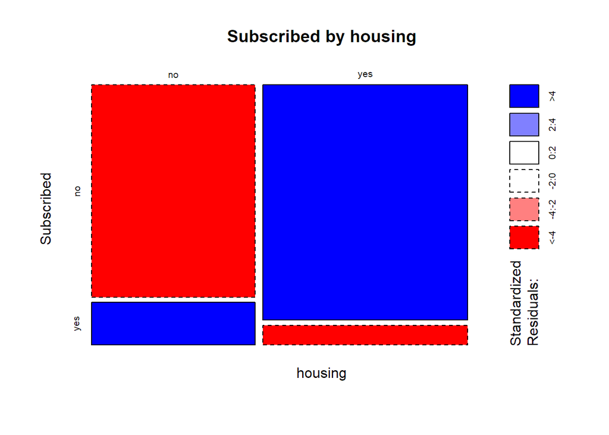

```
##
##
##    Cell Contents
## |-------------------------|
## |                       N |
## | Chi-square contribution |
## |           N / Row Total |
## |           N / Col Total |
## |         N / Table Total |
## |-------------------------|
##
##
## Total Observations in Table:  45211
##
##
##              | y
##       otherC |        no |       yes | Row Total |
## -------------|-----------|-----------|-----------|
##           no |     16727 |      3354 |     20081 |
##              |    56.942 |   429.802 |           |
##              |     0.833 |     0.167 |     0.444 |
##              |     0.419 |     0.634 |           |
##              |     0.370 |     0.074 |           |
## -------------|-----------|-----------|-----------|
##          yes |     23195 |      1935 |     25130 |
##              |    45.501 |   343.449 |           |
##              |     0.923 |     0.077 |     0.556 |
##              |     0.581 |     0.366 |           |
##              |     0.513 |     0.043 |           |
## -------------|-----------|-----------|-----------|
## Column Total |     39922 |      5289 |     45211 |
##              |     0.883 |     0.117 |           |
## -------------|-----------|-----------|-----------|
##
##
## Statistics for All Table Factors
##
##
## Pearson's Chi-squared test
## ------------------------------------------------------------
## Chi^2 =  875.6937     d.f. =  1     p =  1.887099e-192
##
## Pearson's Chi-squared test with Yates' continuity correction
## ------------------------------------------------------------
## Chi^2 =  874.8224     d.f. =  1     p =  2.918798e-192
##
##
```

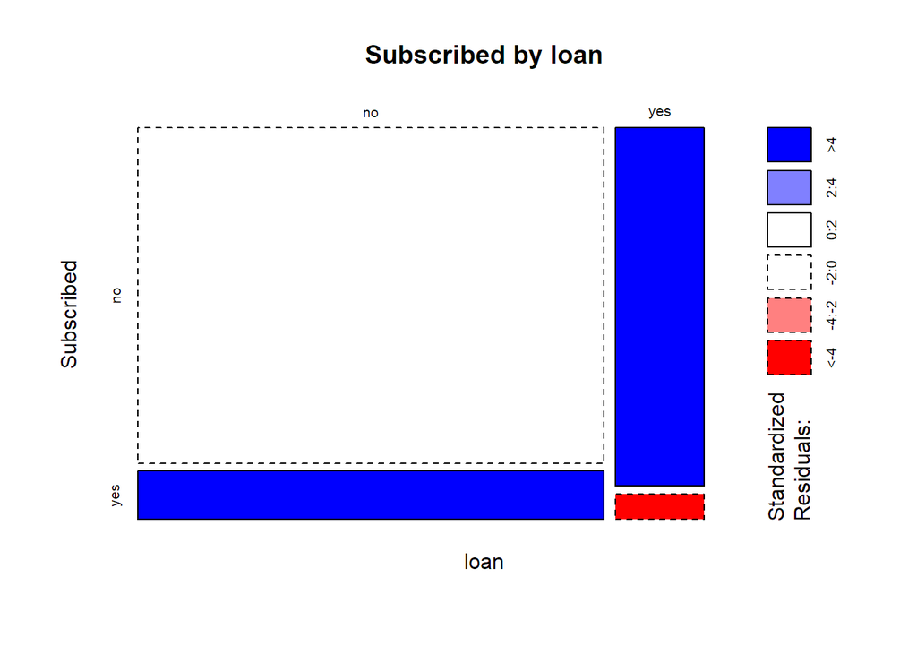

```
##
##
##    Cell Contents
## |-------------------------|
## |                       N |
## | Chi-square contribution |
## |           N / Row Total |
## |           N / Col Total |
## |         N / Table Total |
## |-------------------------|
##
##
## Total Observations in Table:  45211
##
##
##              | y
##       otherC |        no |       yes | Row Total |
## -------------|-----------|-----------|-----------|
##           no |     33162 |      4805 |     37967 |
##              |     3.940 |    29.739 |           |
##              |     0.873 |     0.127 |     0.840 |
##              |     0.831 |     0.908 |           |
##              |     0.733 |     0.106 |           |
## -------------|-----------|-----------|-----------|
##          yes |      6760 |       484 |      7244 |
##              |    20.650 |   155.866 |           |
##              |     0.933 |     0.067 |     0.160 |
##              |     0.169 |     0.092 |           |
##              |     0.150 |     0.011 |           |
## -------------|-----------|-----------|-----------|
## Column Total |     39922 |      5289 |     45211 |
##              |     0.883 |     0.117 |           |
## -------------|-----------|-----------|-----------|
##
##
## Statistics for All Table Factors
##
##
## Pearson's Chi-squared test
## ------------------------------------------------------------
## Chi^2 =  210.1949     d.f. =  1     p =  1.24548e-47
##
## Pearson's Chi-squared test with Yates' continuity correction
## ------------------------------------------------------------
## Chi^2 =  209.617     d.f. =  1     p =  1.665061e-47
##
##
```

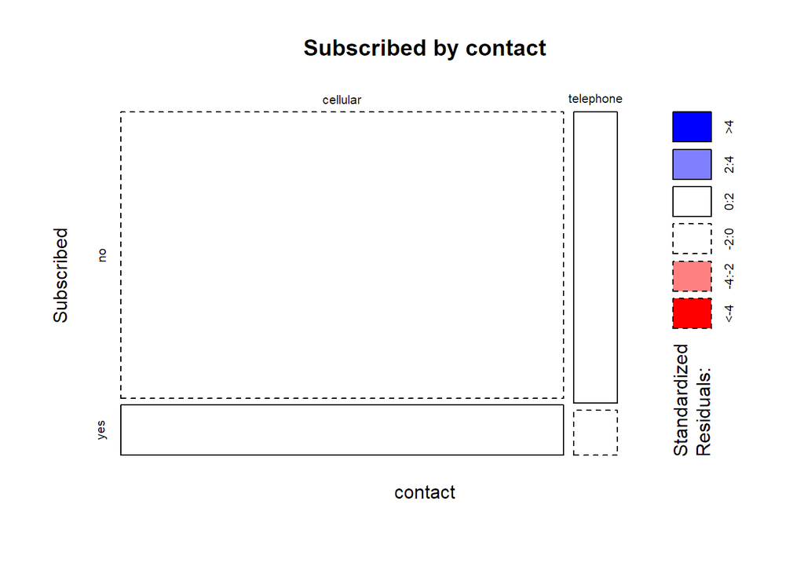

```
##
##
##    Cell Contents
## |-------------------------|
## |                       N |
## | Chi-square contribution |
## |           N / Row Total |
## |           N / Col Total |
## |         N / Table Total |
## |-------------------------|
##
##
## Total Observations in Table:  32191
##
##
##              | y
##       otherC |        no |       yes | Row Total |
## -------------|-----------|-----------|-----------|
##     cellular |     24916 |      4369 |     29285 |
##              |     0.063 |     0.362 |           |
##              |     0.851 |     0.149 |     0.910 |
##              |     0.908 |     0.918 |           |
##              |     0.774 |     0.136 |           |
## -------------|-----------|-----------|-----------|
##    telephone |      2516 |       390 |      2906 |
##              |     0.634 |     3.652 |           |
##              |     0.866 |     0.134 |     0.090 |
##              |     0.092 |     0.082 |           |
##              |     0.078 |     0.012 |           |
## -------------|-----------|-----------|-----------|
## Column Total |     27432 |      4759 |     32191 |
##              |     0.852 |     0.148 |           |
## -------------|-----------|-----------|-----------|
##
##
## Statistics for All Table Factors
##
##
## Pearson's Chi-squared test
## ------------------------------------------------------------
## Chi^2 =  4.711428     d.f. =  1     p =  0.02996276
##
## Pearson's Chi-squared test with Yates' continuity correction
## ------------------------------------------------------------
## Chi^2 =  4.59324     d.f. =  1     p =  0.03209828
##
##
```

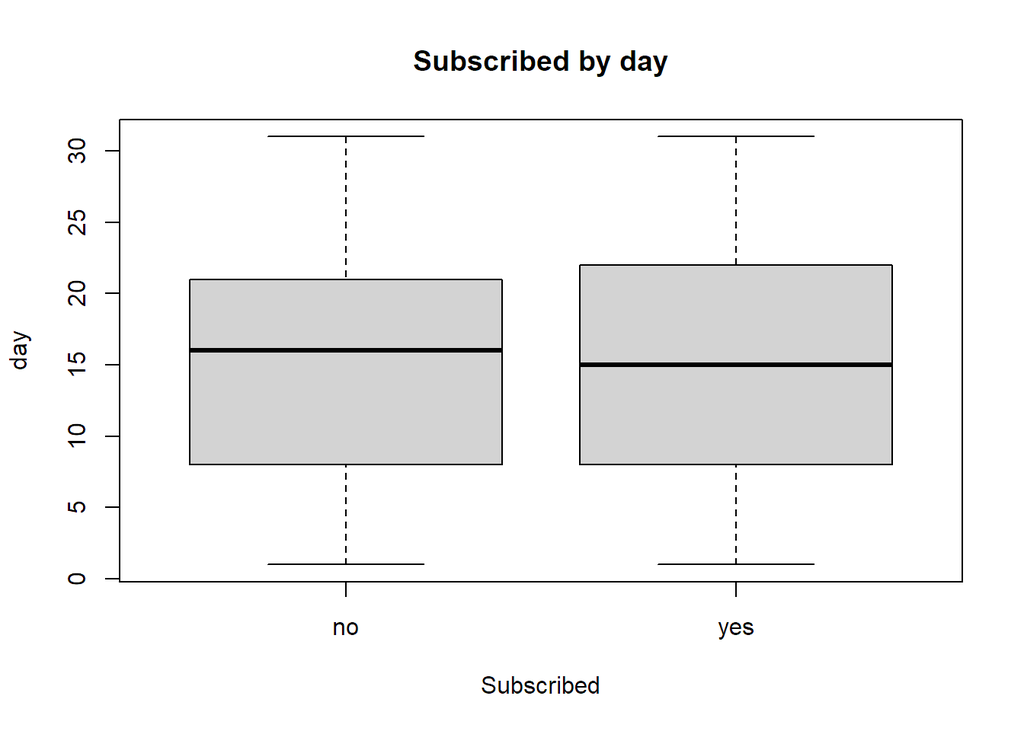

```
##
##  Welch Two Sample t-test
##
## data:  otherC by y
## t = 5.917, df = 6691.7, p-value = 3.441e-09
## alternative hypothesis: true difference in means between group no and group yes is not equal to 0
## 95 percent confidence interval:
##  0.4908478 0.9772262
## sample estimates:
##  mean in group no mean in group yes
##          15.89229          15.15825
```

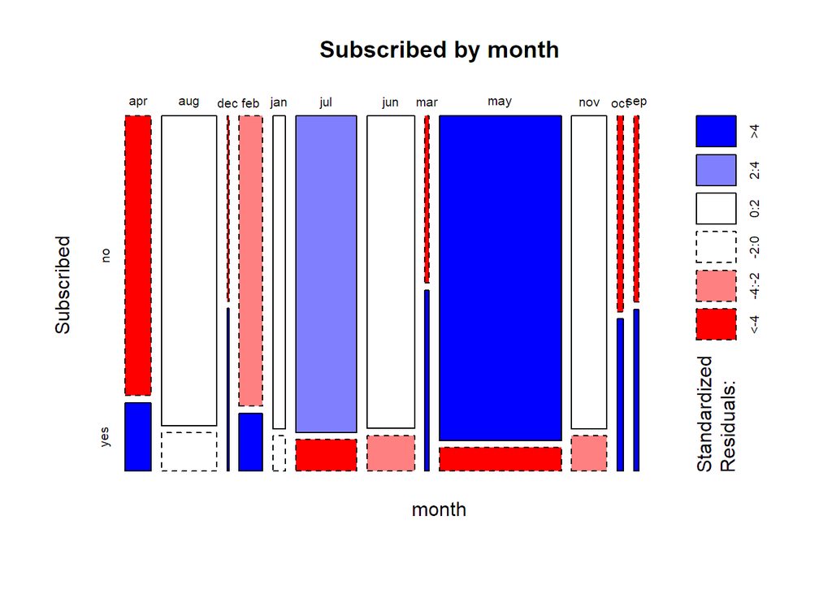

```
##
##
##    Cell Contents
## |-------------------------|
## |                       N |
## | Chi-square contribution |
## |           N / Row Total |
## |           N / Col Total |
## |         N / Table Total |
## |-------------------------|
##
##
## Total Observations in Table:  45211
##
##
##              | y
##       otherC |        no |       yes | Row Total |
## -------------|-----------|-----------|-----------|
##          apr |      2355 |       577 |      2932 |
##              |    21.150 |   159.639 |           |
##              |     0.803 |     0.197 |     0.065 |
##              |     0.059 |     0.109 |           |
##              |     0.052 |     0.013 |           |
## -------------|-----------|-----------|-----------|
##          aug |      5559 |       688 |      6247 |
##              |     0.332 |     2.507 |           |
##              |     0.890 |     0.110 |     0.138 |
##              |     0.139 |     0.130 |           |
##              |     0.123 |     0.015 |           |
## -------------|-----------|-----------|-----------|
##          dec |       114 |       100 |       214 |
##              |    29.740 |   224.480 |           |
##              |     0.533 |     0.467 |     0.005 |
##              |     0.003 |     0.019 |           |
##              |     0.003 |     0.002 |           |
## -------------|-----------|-----------|-----------|
##          feb |      2208 |       441 |      2649 |
##              |     7.349 |    55.468 |           |
##              |     0.834 |     0.166 |     0.059 |
##              |     0.055 |     0.083 |           |
```

[output cut: 49 more lines]

```
## -------------|-----------|-----------|-----------|
## Column Total |     39922 |      5289 |     45211 |
##              |     0.883 |     0.117 |           |
## -------------|-----------|-----------|-----------|
##
##
## Statistics for All Table Factors
##
##
## Pearson's Chi-squared test
## ------------------------------------------------------------
## Chi^2 =  3061.839     d.f. =  11     p =  0
##
##
##
```

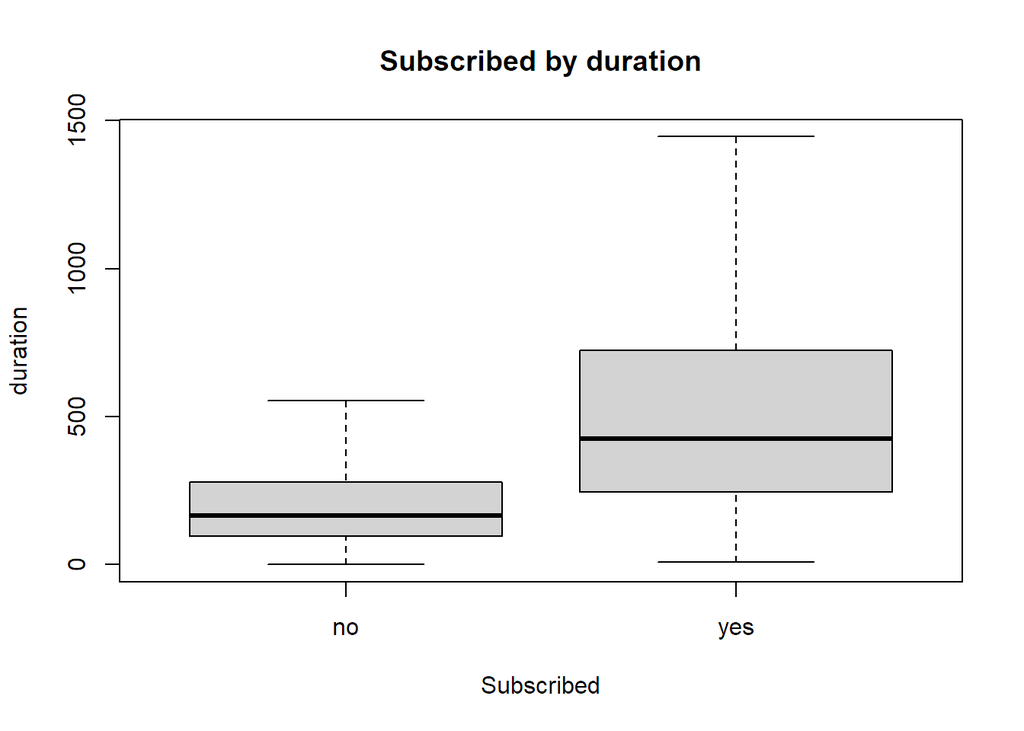

```
##
##  Welch Two Sample t-test
##
## data:  otherC by y
## t = -57.514, df = 5685.3, p-value < 2.2e-16
## alternative hypothesis: true difference in means between group no and group yes is not equal to 0
## 95 percent confidence interval:
##  -326.8865 -305.3370
## sample estimates:
##  mean in group no mean in group yes
##          221.1828          537.2946
```

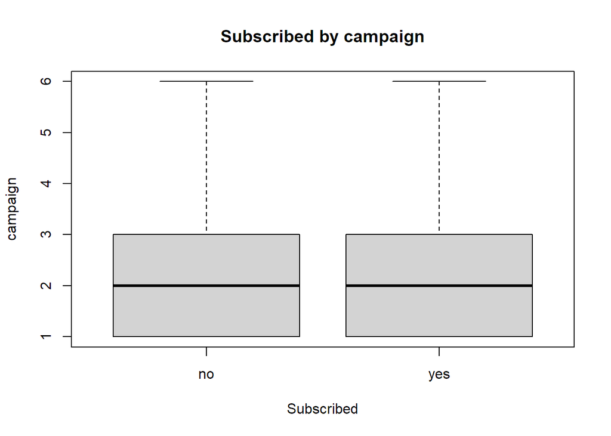

```
##
##  Welch Two Sample t-test
##
## data:  otherC by y
## t = 22.801, df = 9751.6, p-value < 2.2e-16
## alternative hypothesis: true difference in means between group no and group yes is not equal to 0
## 95 percent confidence interval:
##  0.6446672 0.7659387
## sample estimates:
##  mean in group no mean in group yes
##          2.846350          2.141047
```

[3 more figures not shown]

```
##
##
##    Cell Contents
## |-------------------------|
## |                       N |
## | Chi-square contribution |
## |           N / Row Total |
## |           N / Col Total |
## |         N / Table Total |
## |-------------------------|
##
##
## Total Observations in Table:  8252
##
##
##              | y
##       otherC |        no |       yes | Row Total |
## -------------|-----------|-----------|-----------|
##      failure |      4283 |       618 |      4901 |
##              |    69.581 |   232.142 |           |
##              |     0.874 |     0.126 |     0.594 |
##              |     0.675 |     0.325 |           |
##              |     0.519 |     0.075 |           |
## -------------|-----------|-----------|-----------|
##        other |      1533 |       307 |      1840 |
##              |     9.723 |    32.440 |           |
##              |     0.833 |     0.167 |     0.223 |
##              |     0.241 |     0.161 |           |
##              |     0.186 |     0.037 |           |
## -------------|-----------|-----------|-----------|
##      success |       533 |       978 |      1511 |
##              |   340.915 |  1137.398 |           |
##              |     0.353 |     0.647 |     0.183 |
##              |     0.084 |     0.514 |           |
##              |     0.065 |     0.119 |           |
## -------------|-----------|-----------|-----------|
## Column Total |      6349 |      1903 |      8252 |
##              |     0.769 |     0.231 |           |
## -------------|-----------|-----------|-----------|
##
##
## Statistics for All Table Factors
##
##
## Pearson's Chi-squared test
## ------------------------------------------------------------
## Chi^2 =  1822.199     d.f. =  2     p =  0
##
##
##
```

```r
# create ordinal vector for education values for One-Way ANOVA Test
ordinal_education <- bank_full[,"education"]
ordinal_education[which(ordinal_education == "primary")] <- 1
ordinal_education[which(ordinal_education == "secondary")] <- 2
ordinal_education[which(ordinal_education == "tertiary")] <- 3

# create function to determine mode
getMode <- function(c) {
  # only consider non-null values
  uniqueC <- unique(c[!is.na(c)])
  # return value that appears most
  uniqueC[which.max(tabulate(match(c, uniqueC)))]
}

# replace NA vals with the mode of the data so that we can run One-Way ANOVA Test
ordinal_education[which(is.na(ordinal_education))] <- getMode(ordinal_education)

# for each column in the bank dataset, determine the classification of the data by referring to the cat vector and run the appropriate test based on that value
c <- 1
while(c <= length(cat)){
  otherC <- bank_full[,c]
  otherN <- colnames(bank_full[c])

  # skip education, as the data represents ordinal values but is not formatted numerically
  # skip y, as that is the data where are analyzing
  if(otherN == "education"){
    c <- c + 1
    next
  }
  if(cat[c] == n){
    # nominal value, use mosaic plot and chi-sq test
    mosaicplot(table(otherC, y), xlab = otherN, ylab = "Subscribed", main = paste("Subscribed by", otherN), shade=T)
    CrossTable(otherC, y, chisq=T)
  }else{
    # continuous value, use Side-By-Side Boxplot
    boxplot(otherC~y, main = paste("Subscribed by", otherN), xlab = "Subscribed", ylab = otherN, outline=F)
    print(t.test(otherC~y, alternative="two.sided"))
  }
  c <- c + 1
}
```

```r
# manually run One-Way ANOVA test for numerical education values
education_anova <- oneway.test(as.numeric(ordinal_education)~y)

print(education_anova)
```

```
##
##  One-way analysis of means (not assuming equal variances)
##
## data:  as.numeric(ordinal_education) and y
## F = 216.07, num df = 1.0, denom df = 6786.2, p-value < 2.2e-16
```

## Data Preparation:

```r
colSums(is.na(bank_reduced))
```

```
##       job   marital education   default   balance   housing      loan     month
##       288         0      1857         0        50         0         0         0
##  duration     pdays  previous  poutcome         y
##         0     36954         0     36959         0
```

The columns `job`, `education`, `balance`, `pdays`, and `poutcome` all have `NA` values.

```r
# replace NA vals with the mode of the data
bank_reduced[,"job"][which(is.na(bank_reduced[,"job"]))] <- getMode(bank_reduced[,"job"])
bank_reduced[,"education"][which(is.na(bank_reduced[,"education"]))] <- getMode(bank_reduced[,"education"])
bank_reduced[,"poutcome"][which(is.na(bank_reduced[,"poutcome"]))] <- getMode(bank_reduced[,"poutcome"])


# replace NA vals with the mean of the data
bank_reduced[,"balance"][which(is.na(bank_reduced[,"balance"]))] <- mean(bank_reduced[,"balance"], na.rm=T)
bank_reduced[,"pdays"][which(is.na(bank_reduced[,"pdays"]))] <- mean(bank_reduced[,"pdays"], na.rm=T)

colSums(is.na(bank_reduced))
```

```
##       job   marital education   default   balance   housing      loan     month
##         0         0         0         0         0         0         0         0
##  duration     pdays  previous  poutcome         y
##         0         0         0         0         0
```

## Training and Evaluation of ML Models

### Randomization and One-Hot-Encoding

```r
library(data.table)
library(mltools)
set.seed(1)

# shuffle the rows
bank_randomized <- bank_reduced[sample(1:nrow(bank_reduced)),]
#reduced_cat <- c(n, n, o, n, c, n, n, n, c, c, c, n)

# convert ordinal values to numbers
bank_randomized[,"education"][which(bank_randomized[,"education"] == "primary")] <- 1
bank_randomized[,"education"][which(bank_randomized[,"education"] == "secondary")] <- 2
bank_randomized[,"education"][which(bank_randomized[,"education"] == "tertiary")] <- 3

dt <- data.table(bank_randomized)

# convert nominal columns to factors
dt$job <- as.factor(dt$job)
dt$default <- as.factor(dt$default)
dt$housing <- as.factor(dt$housing)
dt$loan <- as.factor(dt$loan)
dt$month <- as.factor(dt$month)
dt$poutcome <- as.factor(dt$poutcome)

# encode factors and convert back into data frame
dt <- one_hot(dt, cols = c("job", "marital", "default", "housing", "loan", "month", "poutcome"), dropUnusedLevels=T)
bank_enc <- as.data.frame(dt)
```

### Z-Score Normalization

```r
# Z-Score Normalization
normalize <- function(x){
  mean <- mean(x)
  sd <- sd(x)

  i <- 1
  while(i <= length(x)){
    x[i] <- (x[i] - mean)/ sd
    i <- i + 1
  }
  return(x)
}

bank_norm <- bank_enc

bank_norm$balance <- normalize(bank_norm$balance)
bank_norm$education <- normalize(as.numeric(bank_norm$education))
bank_norm$duration <- normalize(bank_norm$duration)
bank_norm$pdays <- normalize(bank_norm$pdays)
bank_norm$previous <- normalize(bank_norm$previous)

# split data into training and test sets
training_set <- bank_norm[1:36168,]
test_set <- bank_norm[36169:length(bank_norm),]
```

### Cross Validation

```r
library(caret)
library(class)

# define functions from lectures
knn_fold=function(features,target,fold,k){
  train=features[-fold,]
  validation=features[fold,]
  train_labels=target[-fold]
  validation_labels=target[fold]
  validation_preds=knn(train,validation,train_labels,k=k)
  t= table(validation_labels,validation_preds)
  error=(t[1,2]+t[2,1])/(t[1,1]+t[1,2]+t[2,1]+t[2,2])
  accuracy = 1-error
  return(accuracy)
}

crossValidationError=function(features,target,k){
  folds=createFolds(target,k=10)
  accuracies=sapply(folds,knn_fold,features=features,
  target=target,k=k)
  return(mean(accuracies))
}

# split up the inputs and outputs
training_set_n <- training_set[,1:length(training_set)-1]
training_target <- training_set$y

# store results from different k values to determine the best value for k
k <- c(1, 5, 10, 20, 50, 100, 190)
accuracy <- c(0, 0, 0, 0, 0, 0, 0)
results <- data.frame(k, accuracy)
i <- 1
while(i <= nrow(results)){
  results[i,2] <- crossValidationError(training_set_n, training_target, results[i,1])
  i <- i + 1
}
```

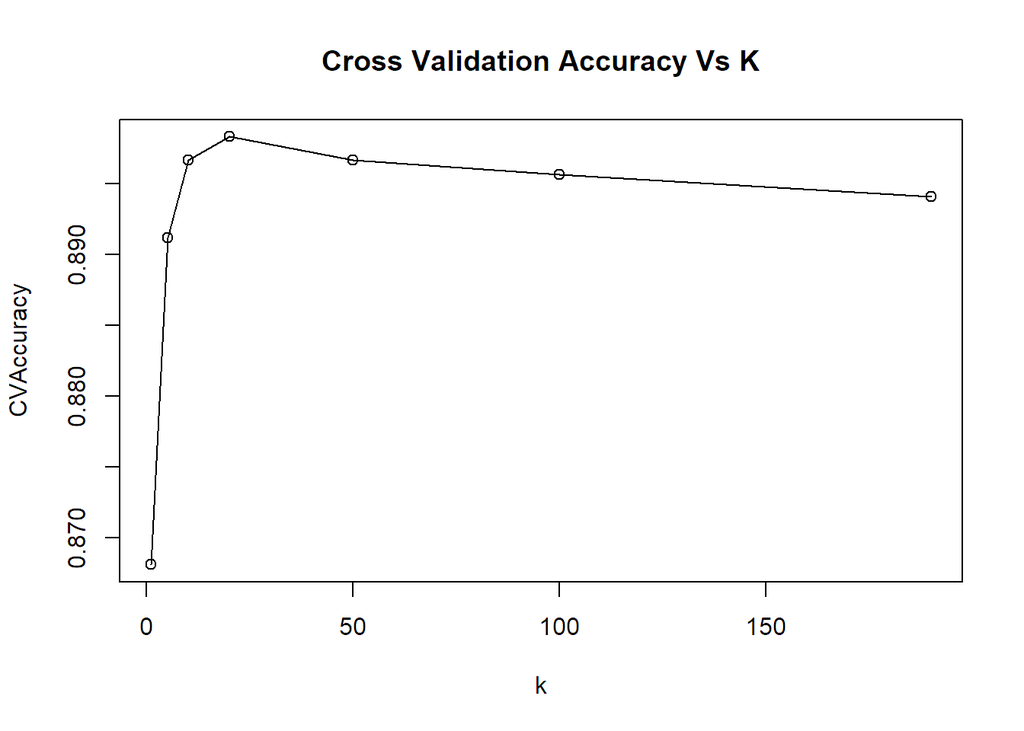

```r
# Plot the results from running the Cross Validations
plot(results[,2]~results[,1], main="Cross Validation Accuracy Vs K", xlab="k", ylab="CVAccuracy")
lines(results[,2]~results[,1])
```

Based on these results, we can see that the value `k` = 20 yields the highest accuracy for the cross validation.

### KNN Training

```r
# train the knn model on the training set and test it on the test set
test_set_n <- test_set[1:length(test_set)-1]
knn_model <- knn(training_set_n, test_set_n, training_target, 20)
```

We can then test the accuracy of the knn model by checking if it is equal to the `y` values in the test set.

### KNN Evaluation

```
## [1] "knn model accuracy: 90.5568471161297%"
```

```
##
##
##    Cell Contents
## |-------------------------|
## |                       N |
## | Chi-square contribution |
## |           N / Row Total |
## |           N / Col Total |
## |         N / Table Total |
## |-------------------------|
##
##
## Total Observations in Table:  36132
##
##
##              | knn_model
##   test_set$y |        no |       yes | Row Total |
## -------------|-----------|-----------|-----------|
##           no |     31260 |       629 |     31889 |
##              |    49.108 |   800.280 |           |
##              |     0.980 |     0.020 |     0.883 |
##              |     0.918 |     0.301 |           |
##              |     0.865 |     0.017 |           |
## -------------|-----------|-----------|-----------|
##          yes |      2783 |      1460 |      4243 |
##              |   369.080 |  6014.641 |           |
##              |     0.656 |     0.344 |     0.117 |
##              |     0.082 |     0.699 |           |
##              |     0.077 |     0.040 |           |
## -------------|-----------|-----------|-----------|
## Column Total |     34043 |      2089 |     36132 |
##              |     0.942 |     0.058 |           |
## -------------|-----------|-----------|-----------|
##
##
```

The knn model does remarkably well predicting `no` values, but is rather lackluster when predicting `yes` values, only successfully predicting them correctly roughly 35% of the time.

### Majority Classifier

A majority classifier that only predicts `no` would correctly classify the outputs 88.2569468% of the time, which is only 2% worse than the knn model.

For the majority classifier, the False Positive Rate would be 0, since it would never predict `yes` when the true value is `no`, and the False Negative Rate would be 1, since it would always predict `no` when the true value is `yes`.

This means the majority classifier performs marginally better in terms of False Positives, but markedly worse in terms of False Negatives.

# Problem 2: Applying Naïve Bayes Classifier to Sentiment Classification of COVID Tweets

## Data Summary

```r
library(data.table)
corona_full <- fread("Corona_NLP_train.csv", encoding="Latin-1")

str(corona_full)
```

```
## Classes 'data.table' and 'data.frame':   41157 obs. of  6 variables:
##  $ UserName     : int  3799 3800 3801 3802 3803 3804 3805 3806 3807 3808 ...
##  $ ScreenName   : int  48751 48752 48753 48754 48755 48756 48757 48758 48759 48760 ...
##  $ Location     : chr  "London" "UK" "Vagabonds" "" ...
##  $ TweetAt      : chr  "16-03-2020" "16-03-2020" "16-03-2020" "16-03-2020" ...
##  $ OriginalTweet: chr  "@MeNyrbie @Phil_Gahan @Chrisitv https://t.co/iFz9FAn2Pa and https://t.co/xX6ghGFzCC and https://t.co/I2NlzdxNo8" "advice Talk to your neighbours family to exchange phone numbers create contact list with phone numbers of neigh"| __truncated__ "Coronavirus Australia: Woolwor…
##  $ Sentiment    : chr  "Neutral" "Positive" "Positive" "Positive" ...
##  - attr(*, ".internal.selfref")=<externalptr>
```

```r
summary(corona_full)
```

```
##     UserName       ScreenName      Location           TweetAt
##  Min.   : 3799   Min.   :48751   Length:41157       Length:41157
##  1st Qu.:14088   1st Qu.:59040   Class :character   Class :character
##  Median :24377   Median :69329   Mode  :character   Mode  :character
##  Mean   :24377   Mean   :69329
##  3rd Qu.:34666   3rd Qu.:79618
##  Max.   :44955   Max.   :89907
##  OriginalTweet       Sentiment
##  Length:41157       Length:41157
##  Class :character   Class :character
##  Mode  :character   Mode  :character
##
##
##
```

## Data Setup

```r
corona_randomized <- corona_full[sample(1:nrow(corona_full)),]
corona_snorm <- corona_randomized
i <- 1
while(i <= nrow(corona_randomized)){
  if(corona_snorm[i, "Sentiment"] == "Extremely Positive"){
    corona_snorm[i, "Sentiment"] <- "Positive"
  }else if(corona_snorm[i, "Sentiment"] == "Extremely Negative"){
    corona_snorm[i, "Sentiment"] <- "Negative"
  }

  i <- i + 1
}
corona_snorm$Sentiment <- factor(corona_snorm$Sentiment)
```

```r
table(corona_snorm$Sentiment)
```

```
##
## Negative  Neutral Positive
##    15398     7713    18046
```

## Cleaning and Standardization

```r
library(tm)
library(SnowballC)

ptweet_corpus <- VCorpus(VectorSource(corona_snorm$OriginalTweet[which(corona_snorm$Sentiment == "Positive")]))
ptweet_corpus_clean <- tm_map(ptweet_corpus, content_transformer(tolower))
ptweet_corpus_clean <- tm_map(ptweet_corpus_clean, removeWords, stopwords())
replacePunctuation <- function(x){
  gsub("[[:punct:]]+", " ", x)
}
ptweet_corpus_clean <- tm_map(ptweet_corpus_clean, content_transformer(replacePunctuation))
ptweet_corpus_clean <- tm_map(ptweet_corpus_clean, stemDocument)
ptweet_corpus_clean <- tm_map(ptweet_corpus_clean, stripWhitespace)
ptweet_corpus_clean <- tm_map(ptweet_corpus_clean, removeWords, c("https", "covid", "coronavirus"))


ntweet_corpus <- VCorpus(VectorSource(corona_snorm$OriginalTweet[which(corona_snorm$Sentiment == "Negative")]))
ntweet_corpus_clean <- tm_map(ntweet_corpus, content_transformer(tolower))
ntweet_corpus_clean <- tm_map(ntweet_corpus_clean, removeWords, stopwords())
ntweet_corpus_clean <- tm_map(ntweet_corpus_clean, content_transformer(replacePunctuation))
ntweet_corpus_clean <- tm_map(ntweet_corpus_clean, stemDocument)
ntweet_corpus_clean <- tm_map(ntweet_corpus_clean, stripWhitespace)
ntweet_corpus_clean <- tm_map(ntweet_corpus_clean, removeWords, c("https", "covid", "coronavirus"))

tweet_corpus <- VCorpus(VectorSource(corona_snorm$OriginalTweet))
tweet_corpus_clean <- tm_map(tweet_corpus, content_transformer(tolower))
tweet_corpus_clean <- tm_map(tweet_corpus_clean, removeWords, stopwords())
tweet_corpus_clean <- tm_map(tweet_corpus_clean, content_transformer(replacePunctuation))
tweet_corpus_clean <- tm_map(tweet_corpus_clean, stemDocument)
tweet_corpus_clean <- tm_map(tweet_corpus_clean, stripWhitespace)
tweet_corpus_clean <- tm_map(tweet_corpus_clean, removeWords, c("https", "covid", "coronavirus"))
```

## Wordclouds

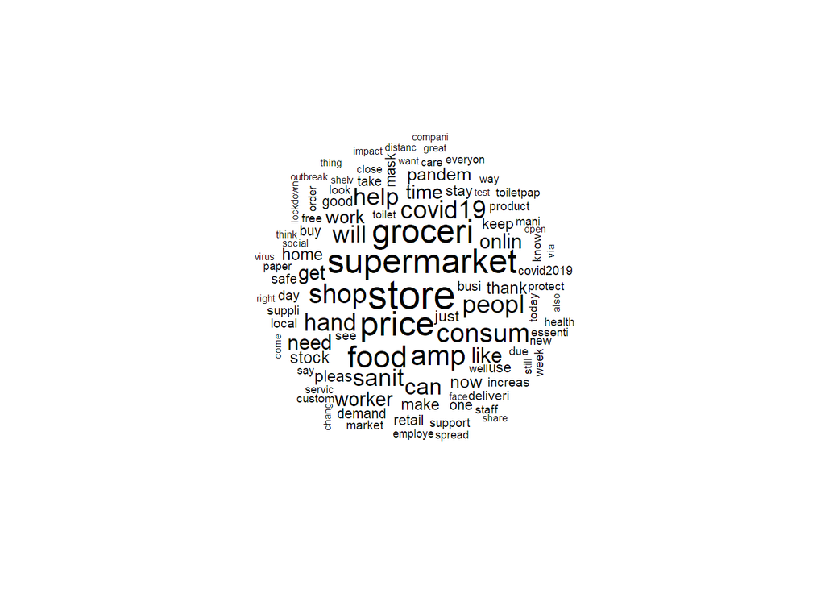

```r
library(wordcloud)
wordcloud(ptweet_corpus_clean, random.order = F, max.words = 100, scale = c(2, .3))
```

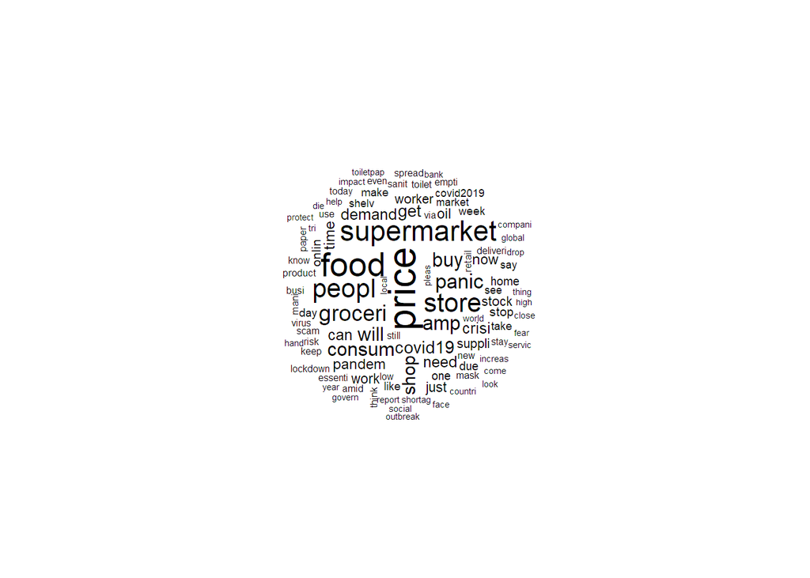

```r
wordcloud(ntweet_corpus_clean, random.order = F, max.words = 100, scale = c(2, .3))
```

After removing “https”, “covid”, and “coronavirus” from each of the corpi, there are not a lot of noticeable differences between the two wordclouds, but the one major difference between the two is that the negative wordcloud’s largest words are price and food, whereas the positive wordcloud’s largest words are store and supermarket. Clearly, much of the frustrations of the negative tweets stem from food availability and skyrocketing prices due to high demand and low supply.

## Document Term Matrices

```r
dtm <- DocumentTermMatrix(tweet_corpus_clean)
training_dtm <- dtm[1:32925,]
testing_dtm <- dtm[32926:nrow(dtm),]

training_dtm_labels <- corona_snorm[1:32925,]$Sentiment
testing_dtm_labels <- corona_snorm[32926:nrow(corona_snorm),]$Sentiment
```

## Create Training and Test Sets

### Calculate Frequency

```r
tweet_freq <- findFreqTerms(training_dtm, 50)
tweet_trainf <- training_dtm[ , tweet_freq]
tweet_testf <- testing_dtm[ , tweet_freq]
```

### Convert Frequencies to Binary Features

```r
convert_counts <- function(x){
  x <- ifelse(x >0, "Yes", "No")
}

train <- apply(tweet_trainf, MARGIN = 2, convert_counts)
test <- apply(tweet_testf, MARGIN = 2, convert_counts)
```

## Create and Test Classifier

```r
library(e1071)
classifier <- naiveBayes(train, training_dtm_labels)
pred <- predict(classifier, test)
```

## Results

### Accuracy

```
##                   pred
## testing_dtm_labels Negative Neutral Positive
##           Negative     2157     405      564
##           Neutral       214    1075      241
##           Positive      597     462     2517
```

The overall accuracy of the model is 5749 / 8232 = 69.8372206%

### Precision and Recall

#### Positive Class

Positive Precision: 0.7576761  
Positive Recall: 0.7038591

#### Neutral Class

Neutral Precision: 0.553553  
Neutral Recall: 0.7026144

#### Negative Class

Negative Precision: 0.726752  
Negative Recall: 0.6900192